# First, I am going to read the largest files (Master, Batting, Pitching, Fielding) and explore them a bit to understand the data at hand. I also read through the ReadME file to understand all the stats

# Analyzing the best HOF Catchers' Defense

# First, I'm comparing basic defensive stats to the average player post 1949 - Passed Balls, Stolen Bases, Opponents Caught Stealing, and Total Attempted Steals

```python
# # Cutting the fielding data for only the players that played after 1949
# # and started more than the average number of games

fielding = fielding.merge(master, on= 'playerID')

fielding = fielding[fielding['POS'] == 'C']

playerID_od_c['Attempts'] = playerID_od_c['SB_fielding'] + playerID_od_c['CS_fielding']

fielding['Attempts'] = (fielding['SB'] + fielding['CS'])

fielding_post = fielding[fielding['yearID'] >= 1949]

fielding_post['In_HOF'] = fielding_post.playerID.isin(hof_catcher_playerID)

fielding_post = fielding_post.set_index(['playerID', 'nameFirst', 'nameLast'])

fielding_groupID = fielding_post.groupby(level = ['playerID', 'nameFirst', 'nameLast']).sum()

# batting_starter_catchers = batting_starter_catchers.groupby(level = ['playerID', 'nameFirst', 'nameLast']).sum()

print(fielding_groupID['G'].mean())

fielding_starters = fielding_groupID[fielding_groupID['G'] > 289]
```

```
275.933273219
```

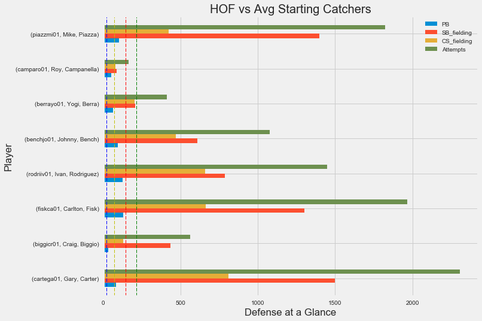

```python
# batting_AB = batting_groupID['AB'].mean()

defense_PB = fielding_groupID['PB'].mean()
defense_SB = fielding_groupID['SB'].mean()
defense_CS = fielding_groupID['CS'].mean()
defense_attempts = fielding_groupID['Attempts'].mean()

# plt.style.available
plt.style.use('fivethirtyeight')

fig, ax = plt.subplots(figsize =(10,8))

playerID_od_c.plot(kind='barh', y=['PB', 'SB_fielding', 'CS_fielding', 'Attempts'], ax=ax)

ax.set(title='HOF vs Avg Starting Catchers', xlabel = 'Defense at a Glance', ylabel = 'Player')

# ax.axvline(x = defense_ZR, color='b', label='Average', linestyle='--', linewidth=1)

ax.axvline(x = defense_PB, color='b', label='Average', linestyle='--', linewidth=1)

ax.axvline(x = defense_SB, color='r', label='Average', linestyle='--', linewidth=1)

ax.axvline(x = defense_CS, color='y', label='Average', linestyle='--', linewidth=1)

ax.axvline(x = defense_attempts, color='g', label='Average', linestyle='--', linewidth=1)
```

# Looking at basic catching stats, it's apparent that some of the catchers had different experiences with the runners in the league at the time. To understand a catchers' skill at throwing out the runner, let's take a look at the catchers' Average at Throwing Out a runner.

```python
# Prepping data to be graphed
# Filtering for only catchers who played more than the average
# number of games to filter for Starting Catchers.
# Also, creating a 'Put_Out_Avg' for catchers, which is runners
# caught stealing divided by number of attempted steals to understand
# a catchers' effectiveness at throwing out runners.

fielding_starters['Put_Out_Avg'] = fielding_starters['CS']/fielding_starters['Attempts']

print(fielding_starters['G'].mean())

fielding_starters = fielding_starters.fillna(value = 0)

# Setting Roy Campanella's In_HOF value higher because groupby
# counts the number of True/False's to assign a numerical value
# to the dimension 'In_HOF' when in a groupby.

# I'm doing this because Roy Camapanella had a shorter career
# making his count of 'In_HOF' Trues substantially less than the
# other HOFers, which made his colored point lighter than the other
# HOFers. Same for Craig Biggio who was only a Catcher in the very
# beginning of his career.

fielding_starters = fielding_starters.set_value('camparo01', 'In_HOF', 20)

fielding_starters = fielding_starters.set_value('biggicr01', 'In_HOF', 20)

fielding_starters.head()
```

```
744.566860465
```

| playerID | nameFirst | nameLast | yearID | stint | G | GS | InnOuts | PO | A | E | DP | PB | WP | SB | CS | ZR | Attempts | In_HOF | Put_Out_Avg |
| --- | --- | --- | --- | --- | --- | --- | --- | --- | --- | --- | --- | --- | --- | --- | --- | --- | --- | --- | --- |
| allanan01 | Andy | Allanson | 15921 | 8 | 501 | 453.0 | 11965.0 | 2395 | 208.0 | 52.0 | 24.0 | 41.0 | 125.0 | 292.0 | 129.0 | 4.0 | 421.0 | 0.0 | 0.306413 |
| allenga01 | Gary | Allenson | 13874 | 7 | 399 | 342.0 | 8959.0 | 1762 | 146.0 | 32.0 | 24.0 | 27.0 | 45.0 | 233.0 | 110.0 | 5.0 | 343.0 | 0.0 | 0.320700 |
| alomasa02 | Sandy | Alomar | 41970 | 23 | 1324 | 1203.0 | 31914.0 | 7667 | 464.0 | 86.0 | 72.0 | 71.0 | 239.0 | 758.0 | 328.0 | 4.0 | 1086.0 | 0.0 | 0.302026 |
| arencjp01 | J. P. | Arencibia | 12075 | 6 | 400 | 370.0 | 9950.0 | 2691 | 200.0 | 24.0 | 12.0 | 39.0 | 0.0 | 228.0 | 83.0 | 0.0 | 311.0 | 0.0 | 0.266881 |
| ashbyal01 | Alan | Ashby | 33677 | 17 | 1299 | 1191.0 | 31540.0 | 7086 | 684.0 | 113.0 | 74.0 | 113.0 | 333.0 | 1112.0 | 445.0 | 13.0 | 1557.0 | 0.0 | 0.285806 |

```python
# Scatter plotting data for average catcher's Put Out Avg
fig, ax = plt.subplots(figsize =(10,10))
plt.subplots_adjust(bottom=0.1, right=0.8, top=0.9)
ax.set(title='Starting Catchers Put Out Avg', xlabel = 'Put Out Avg', ylabel = 'G')

colors = fielding_starters['In_HOF']

points = ax.scatter(fielding_starters['G'], fielding_starters['Put_Out_Avg'], c = colors)

#Regression line
sns.regplot(data=fielding_starters, x="G", y="Put_Out_Avg", ax=ax)

# mpld3 to make scatter plot interactive
labels = fielding_starters.index.tolist()
tooltip = mpld3.plugins.PointLabelTooltip(points, labels, hoffset = 70, voffset = 50)
mpld3.plugins.connect(fig, tooltip)
mpld3.display(fig)
```

[output not shown]